# transition_maker

## Transition Maker

**Author**: Andrew Smelser

**Author Email**:

**Date Tested**: 02/14/2020

**Description**: A script written in Python 3.7 to create a transition with shoulder for two given airframe size. The transition will have a hollow interior with constant wall thickness of value `k`. The coordinates of the transition will be produced as a 2D matrix and printed to a .csv file for use in OpenSCAD.

**Requirements**:

- Python 3.7.6+
- Jupyter NoteBook 6.0.2+
- Shapely 1.6.4+
- Matplotlib 3.1.1+
- Numpy 1.17.3+

### Instructions

1. Define the parameters below in cell 1
2. Click "restart the kernel, then re-run the whole notebook"
3. Wait for the NoteBook to run
4. Open the file that was just created and copy its contents
5. Paste those contents into an OpenSCAD file
6. Run the OpenSCAD file
7. It should produce a transition with the parameters you have defined

### User Parameters

**alpha** Aft shoulder inner diameter, mm. Same value as aft airframe inner diameter.

**beta** Aft shoulder outer diameter, mm. Same value as aft airframe outer diameter.

**gamma** Fore shoulder outer diameter, mm. Same value as fore airframe outer diameter.

**delta** Fore shoulder inner diameter, mm. Same value as fore airframe inner diameter.

**epsilon_1** Length of aft shoulder, mm.

**epsilon_2** Length of transision section, mm. Leave as _ to calculate length from slope.

**epsilon_3** Length of fore shoulder, mm.

**theta** Slope of transition section, degrees. To use a specified epsilon_2 length set theta=None

**output_filename** The name of the save file containing the OpenSCAD code.

### Default Test Values

`alpha = 38` # Aft shoulder inner diameter, mm. Same value as aft airframe inner diameter.

`beta = 40` # Aft shoulder outer diameter, mm. Same value as aft airframe outer diameter.

`gamma = 24` # Fore shoulder outer diameter, mm. Same value as fore airframe outer diameter.

`delta = 22` # Fore shoulder inner diameter, mm. Same value as fore airframe inner diameter.

`epsilon_1 = 40` # Length of aft shoulder, mm.

`epsilon_2 = _` # Length of transision section, mm. Leave as _ to calculate length from slope.

`epsilon_3 = 24` # Length of fore shoulder, mm.

`theta = 30` # Slope of transition section, degrees. To use a specified epsilon_2 length set theta=None

`output_filename = 'test_transition_1.csv'`

See the `tests/TransitionMaker` folder for the outputs of the test.

### Notes

- Don't edit any cell other than the first cell where you will enter the user inputs.
- The coordinates produced can be used in other CAD programs.
  - The transition profile is designed to be created by a revolve-extrude operation around the x-axis.
  - Attempts to test a similar program as this one (transition_maker) were not successful in Solid Edge, but it is likely that it could be made to work.
- This code was developed and tested only in Jupyter NoteBook. Attempts might be made later to transition all the code and related codes to a PyCharm project. If you attempt this and run into issues please let the developer know!

### TODO

- Add functionality to create bulkhead 'shelves' inside the transition for avionics mounting.

```python
# ===== User input parameters ===== #
alpha = 38  # Aft shoulder inner diameter, mm. Same value as aft airframe inner diameter.
beta = 40  # Aft shoulder outer diameter, mm. Same value as aft airframe outer diameter.
gamma = 24  # Fore shoulder outer diameter, mm. Same value as fore airframe outer diameter.
delta = 22  # Fore shoulder inner diameter, mm. Same value as fore airframe inner diameter.
epsilon_1 = 40  # Length of aft shoulder, mm.
epsilon_2 = _  # Length of transision section, mm. Leave as _ to calculate length from slope.
epsilon_3 = 24  # Length of fore shoulder, mm.
theta = 30  # Slope of transition section, degrees. To use a specified epsilon_2 length set theta=None
output_filename = 'test_transition_1.csv'

# ===== DO NOT EDIT BELOW THIS LINE ===== #
epsilons=(epsilon_1, epsilon_2, epsilon_3)
```

```python
# Define the functions that will create the transition plot

from shapely.geometry import Point, LineString
import matplotlib.pyplot as plt
import numpy as np
import os


def transition_all(alpha, beta, gamma, delta, epsilons, theta=None):
    """Create a transition

    :param alpha: aft shoulder diameter, mm. The same as the inner diameter of the aft airframe
    :type alpha: int, float
    :param beta: aft airframe outer diameter, mm.
    :type beta: int, float
    :param gamma: fore airframe outer diameter, mm.
    :type gamma: int, float
    :param delta: Fore airframe inner diameter, mm.
    :type delta: int, float
    :param epsilons: A three-element tuple or list of the segment lengths;
        epsilon_1 is the length of the aft shoulder in mm
        epsilon_2 is the length of the transision section in mm
        epsilon_3 is the length of the fore shoulder in mm
    :type epsilons: list, tuple
    :param theta: The slope angle of the transision in degrees. Use ``None`` to specify an epsilon value.
    :type theta: int, float, None

    Note: Enter all measurements in millimeters. Conversion to radius is taken care of in the program.

    Example Usage:
        transition_line, eps = transition_all(
            alpha=38,
            beta=40,
            gamma=24,
            delta=22,
            epsilons=(40,_,24),
            theta=45
            )

        transition_line2, eps2 = transition_all(
            alpha=38,
            beta=40,
            gamma=24,
            delta=22,
            epsilons=(40,30,24),
            theta=None
            )
    """

    # Convert diameters to radii
    _alpha = alpha/2
    _beta = beta/2
    _gamma = gamma/2
    _delta = delta/2

    epsilon_1 = epsilons[0]
    epsilon_3 = epsilons[2]
    if theta is None:
        # Use epsilon_2 value and ignore theta value
        epsilon_2 = epsilons[1]
    else:
        # Use theta value to calculate epsilon_2 value
        # must use diameter beta and gamma values
        epsilon_2 = (beta - gamma) / np.tan(theta*np.pi/180)

    A = (0, _alpha)
    B = (epsilon_1, _alpha)
    C = (epsilon_1, _beta)
    D = (epsilon_1 + epsilon_2, _gamma)
    E = (epsilon_1 + epsilon_2, _delta)
    F = (epsilon_1 + epsilon_2 + epsilon_3, _delta)
    G = (epsilon_1, _gamma)
    nc_shape = LineString([A, B, C, D, E, F])
    return nc_shape, tuple([epsilon_1, epsilon_2, epsilon_3])


def transition_offset_wall(transition_line, k):
    """Create an offset surface for the transition

    Call transition_all(...) before calling this function.

    :param transition_line: The Shapely LineString object which defines the initial surface of the transision.
    :type transition_line: shapely.LineString
    :param k: Wall thickness, mm.
    :type k: float
    """
    k = float(k)  # force k to be a float

    if k < 0:
        side='left'
    elif k > 0:
        side='right'
    else:
        raise InputError('Unknown error encountered when handling k value.')

    offset_line = transition_line.parallel_offset(
        distance=abs(k),
        side=side,
        join_style=2
    )

    return transition_line, offset_line


def plot_coords(line_coords, openscad=True):
    """Show the plot of the lines

    Call transition_offset_wall(...) before calling this function

    :param line_coords: Shapely LineString object that represents the transition
    :type line_coords: shapely.LineString, list
    :param openscad: Boolean that indicates whether or not coordinate pairs should be returned for use in OpenSCAD. Default is True.
    :type openscad: bool
    """
    %matplotlib notebook
    fig = plt.figure()
    ax = fig.add_subplot(111)
    ax.axis('equal')

    loc_coords_copy = list()
    for _coords in line_coords:
        loc_coords = np.array([list(x) for x in _coords.coords])
        x_coords = loc_coords[:, 0]
        y_coords = loc_coords[:, 1]
        ax.plot(x_coords, y_coords, color='b')
        loc_coords_copy.append(loc_coords)
    plt.ylim(0, max(y_coords)+2)
    plt.xlim(0, max(x_coords)+2)

    aft_end_line_x = [loc_coords_copy[0][0][0], loc_coords_copy[1][-1][0]]
    aft_end_line_y = [loc_coords_copy[0][0][1], loc_coords_copy[1][-1][1]]
    fore_end_line_x = [loc_coords_copy[0][-1][0], loc_coords_copy[1][0][0]]
    fore_end_line_y = [loc_coords_copy[0][-1][1], loc_coords_copy[1][0][1]]
    plt.plot(aft_end_line_x, aft_end_line_y, color='b')
    plt.plot(fore_end_line_x, fore_end_line_y, color='b')

    ax = plt.gca()
    x_vals = np.array([])
    y_vals = np.array([])
    for i in range(len(ax.lines)):
        line_x = ax.lines[i].get_xdata()
        line_y = ax.lines[i].get_ydata()
        x_vals = np.concatenate((x_vals, line_x), axis=0)
        y_vals = np.concatenate((y_vals, line_y), axis=0)
    coord_pairs = np.vstack((x_vals, y_vals)).T

    if openscad:
        coord_pairs = coord_pairs[:13]
    return loc_coords_copy, coord_pairs

def write_to_file(coord_pairs, filename):
    """Write the coordinate pairs to a csv file

    Write coordinate pairs to a .csv file for copy and paste
    into OpenSCAD

    :param coord_pairs: A NumPy array of x and y coordinates for the nosecone
    :type coord_pairs: np.array
    :param filename: The name of the output file. Must contain the file extension.
    :type filename: str, PathLike
    """
    filename = os.path.join(os.getcwd(), filename)
    rows, _ = coord_pairs.shape
    i = 0
    max_length = max(coord_pairs.T[0])
    header = f"""rotate_extrude($fn=200)
\trotate([0,0,90])
\t\ttranslate([0,0,0])
\t\t\tpolygon(
\t\t\t\tpoints=[
"""
    with open(filename, mode='w', newline='') as fout:
        fout.write(header)
        for row in coord_pairs:
            i = i + 1
            if i == rows:
                write_str = f'\t\t\t\t\t[{row[0]},{row[1]}]\n\t\t\t\t]\n\t\t\t);'
            else:
                write_str = f'\t\t\t\t\t[{row[0]},{row[1]}],\n'
            fout.write(write_str)
    print('File created: {}'.format(filename))
    return True


def main(filename):
    """Call all the functions to produce the transition

    :param filename: The name of the output file.
    :type filename: str, PathLike
    """
    line_primary, epsilon_vals = transition_all(
    alpha=alpha,
    beta=beta,
    gamma=gamma,
    delta=delta,
    epsilons=epsilons,
    theta=theta
    )
    line1, line2 = transition_offset_wall(transition_line=line_primary, k=1)
    lcc, coord_pairs = plot_coords([line1, line2])
    write_to_file(coord_pairs=coord_pairs, filename=filename)
```

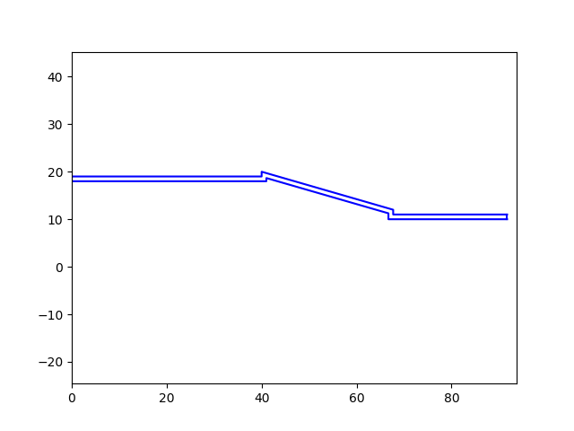

```
File created: C:\Users\asmelser\Documents\Python\Jupyter\JupyterNotebook\Nosecones\test_transition_1.csv
```

```python
# Call the functions to obtain the transition
main(filename=output_filename)
```